# Civilian Complaints Against New York City Police Officers (1985 - 2020)

Source:  
https://www.propublica.org/datastore/dataset/civilian-complaints-against-new-york-city-police-officers  
https://www1.nyc.gov/site/nypd/stats/crime-statistics/historical.page

**Is there a racial bias in civilian complaints?**

| Officer ethnicity | Complainant ethnicity | Civilian Complaints |
| --- | --- | --- |
| White | Black | 8970 |
| Hispanic | Black | 4722 |
| White | Hispanic | 3262 |
| Black | Black | 2846 |
| White | NA | 2787 |
| Hispanic | Hispanic | 2215 |
| White | White | 1647 |
| Hispanic | NA | 937 |
| Black | Hispanic | 709 |
| Hispanic | White | 625 |

[output cut: 32 more lines]

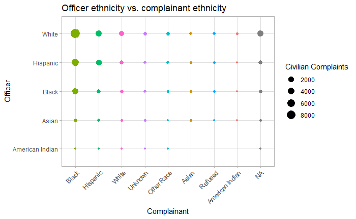

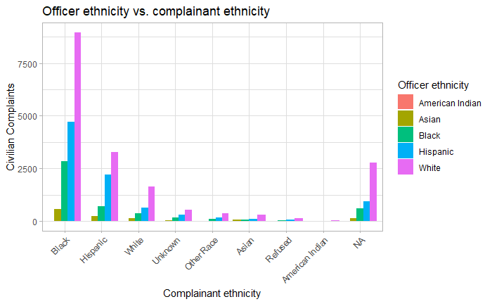

**Composition by officer ethnicity:**

| Officer ethnicity | count | %comp |
| --- | --- | --- |
| White | 18074 | 54.18 |
| Hispanic | 9150 | 27.43 |
| Black | 4924 | 14.76 |
| Asian | 1178 | 3.53 |
| American Indian | 32 | 0.10 |

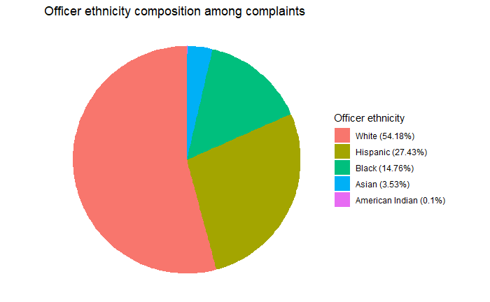

The majority of complaints involve White officers.  
As of 2010, 53% of the entire 34,526-member police force were white and 47% were members of minority groups.  
(https://en.wikipedia.org/wiki/New_York_City_Police_Department#Demographics)

**Composition by complainant ethnicity:**

| complainant_ethnicity | count | %comp |
| --- | --- | --- |
| Black | 17114 | 51.30 |
| Hispanic | 6424 | 19.26 |
| NA | 4464 | 13.38 |
| White | 2783 | 8.34 |
| Unknown | 1041 | 3.12 |
| Other Race | 677 | 2.03 |
| Asian | 532 | 1.59 |
| Refused | 259 | 0.78 |
| American Indian | 64 | 0.19 |

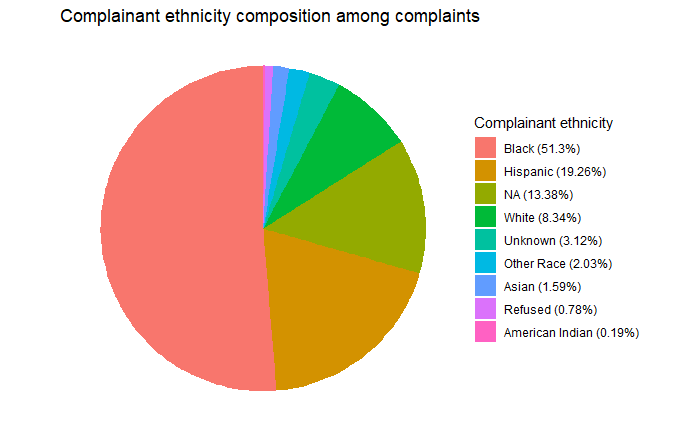

Half of the civilians who file complaints are Black. As of the 2010 census, the black population in NY is 25%.  
https://en.wikipedia.org/wiki/Demographic_history_of_New_York_City#Citywide

**Are there officers with repeat complaints against them?**

| unique_mos_id | first_name | last_name | Complaints |
| --- | --- | --- | --- |
| 18731 | Daniel | Sbarra | 75 |
| 25861 | Mathew | Reich | 75 |
| 18530 | Joseph | Tallarine | 73 |
| 19489 | Gary | Messina | 73 |
| 18589 | Christophe | Mccormack | 72 |
| 25814 | William | Taylor | 65 |
| 22775 | David | Cheesewright | 63 |
| 20982 | Mike | Civil | 56 |
| 25478 | Paul | Mcmahon | 56 |
| 32054 | Michael | Raso | 50 |

[output cut: 990 more lines]

It is a little shocking how many officers have repeat complaints against them and, but more shocking is the amount of complaints against a given officer. These complaints go back to 1985.

**How many were there in 2019?**

| unique_mos_id | first_name | last_name | Complaints |
| --- | --- | --- | --- |
| 5752 | David | Ramirez | 29 |
| 14885 | Scott | Hampton | 18 |
| 11620 | Michael | Hawk | 15 |
| 25700 | Richard | Charles | 15 |
| 5364 | Kyron | Delarosa | 14 |
| 11263 | Gregg | Minardi | 14 |
| 22881 | David | Grieco | 14 |
| 35920 | Robert | Gallagher | 14 |
| 5642 | Miguel | Donovan | 13 |
| 6463 | Alena | Aminova | 11 |

[output cut: 522 more lines]

| n |
| --- |
| 1642 |

There were 1,642 complaints in 2019 from 532 officers. There are currently 38,421 sworn officers in the NYPD  
(https://en.wikipedia.org/wiki/New_York_City_Police_Department)  
This equates to 1.38% of the NYPD officers who have had complaints filed against them in 2019.

**How have the number of complaints changed over time?**

| year_received | Complaints |
| --- | --- |
| 2019 | 1642 |
| 2018 | 2281 |
| 2017 | 2178 |
| 2016 | 2345 |
| 2015 | 2312 |
| 2014 | 2220 |
| 2013 | 2114 |
| 2012 | 1841 |
| 2011 | 1896 |
| 2010 | 1659 |

[output cut: 25 more lines]

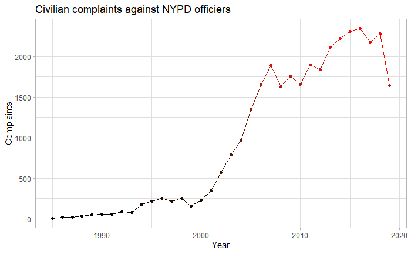

**How many officers are involved in complaints every year?**

| year_received | Officers |
| --- | --- |
| 2019 | 532 |
| 2018 | 727 |
| 2017 | 701 |
| 2016 | 746 |
| 2015 | 807 |
| 2014 | 756 |
| 2013 | 756 |
| 2012 | 706 |
| 2011 | 708 |
| 2010 | 643 |

[output cut: 25 more lines]

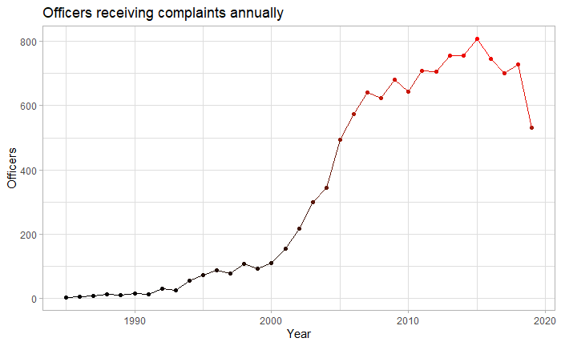

**How does the number of officers look plotted with the number of complaints?**

| year_received | Officers | Complaints | complaints_per_officer |
| --- | --- | --- | --- |
| 1985 | 4 | 7 | 2 |
| 1986 | 7 | 22 | 3 |
| 1987 | 8 | 22 | 3 |
| 1988 | 13 | 35 | 3 |
| 1989 | 10 | 49 | 5 |
| 1990 | 17 | 54 | 3 |
| 1991 | 14 | 56 | 4 |
| 1992 | 30 | 88 | 3 |
| 1993 | 26 | 76 | 3 |
| 1994 | 56 | 177 | 3 |

[output cut: 25 more lines]

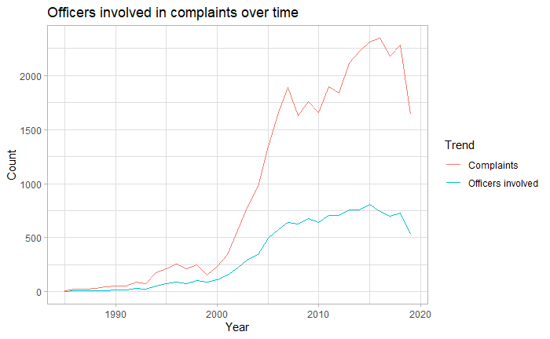

The number of officers involved started leveling off in 2005, but the number of complaints kept increasing.

**What are the most common complaints?**

| fado_type | allegation | allegation_count |
| --- | --- | --- |
| Abuse of Authority | Stop | 2300 |
| Abuse of Authority | Search (of person) | 2047 |
| Abuse of Authority | Frisk | 1926 |
| Abuse of Authority | Premises entered and/or searched | 1555 |
| Abuse of Authority | Refusal to provide name/shield number | 1483 |
| Abuse of Authority | Vehicle search | 1405 |
| Abuse of Authority | Threat of arrest | 1370 |
| Abuse of Authority | Vehicle stop | 1094 |
| Abuse of Authority | Threat of force (verbal or physical) | 912 |
| Abuse of Authority | Question and/or stop | 696 |

[output cut: 109 more lines]

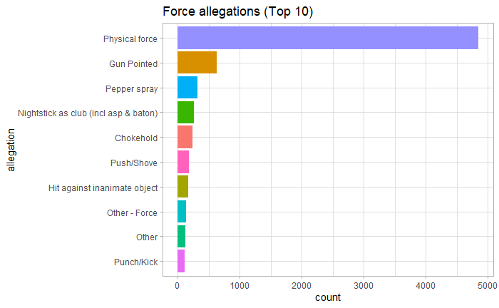

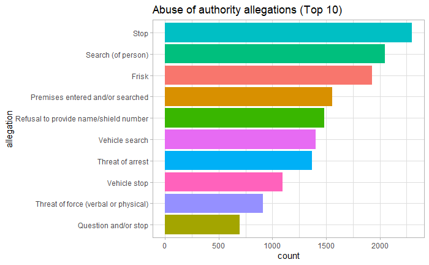

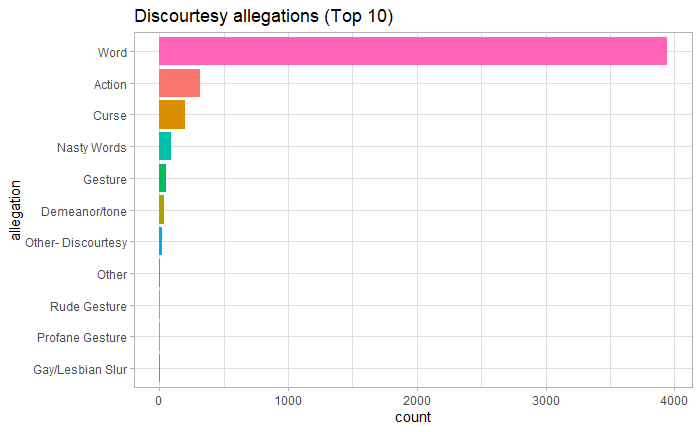

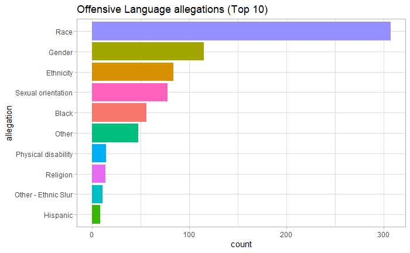

**How are the complaints classified?**

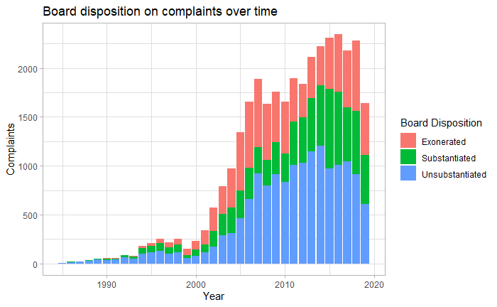

**Precint distribution**

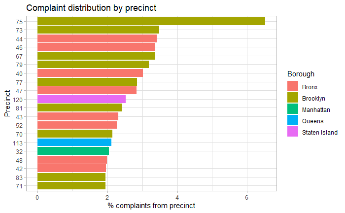

**How does the number of allegations trend with total crime in that precinct?**

| precinct | complaints | precinct% | Address | Borough | total_crime | complaints_per_crime | complaints_per_crime_norm |
| --- | --- | --- | --- | --- | --- | --- | --- |
| 75 | 2096 | 6.614908793 | 1000 Sutter Avenue | Brooklyn | 395298 | 0.0053023289 | 2.416294740 |
| 73 | 1148 | 3.623051190 | 1470 East New York Avenue | Brooklyn | 253640 | 0.0045261000 | 1.789268430 |
| 44 | 1086 | 3.427381178 | 2 East 169th Street | Bronx | 320547 | 0.0033879587 | 0.869894605 |
| 46 | 1073 | 3.386353595 | 2120 Ryer Avenue | Bronx | 286293 | 0.0037479086 | 1.160656856 |
| 67 | 1055 | 3.329546172 | 2820 Snyder Avenue | Brooklyn | 232280 | 0.0045419322 | 1.802057421 |
| 79 | 1021 | 3.222243262 | 263 Tompkins Avenue | Brooklyn | 210255 | 0.0048560082 | 2.055763430 |
| 40 | 984 | 3.105472448 | 257 Alexander Avenue | Bronx | 310469 | 0.0031693986 | 0.693344920 |
| 47 | 907 | 2.862462917 | 4111 Laconia Avenue | Bronx | 226692 | 0.0040010234 | 1.365119281 |
| 77 | 894 | 2.821435334 | 127 Utica Avenue | Brooklyn | 184241 | 0.0048523401 | 2.052800442 |
| 120 | 833 | 2.628921290 | 78 Richmond Terrace | Staten Island | 240198 | 0.0034679723 | 0.934528375 |

[output cut: 69 more lines]

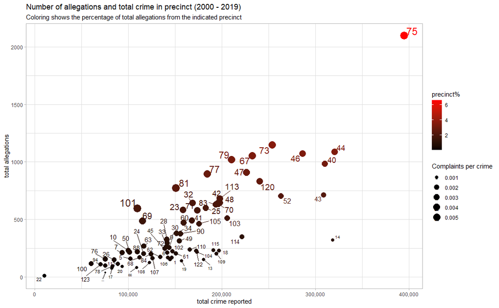

**Can the number of crimes predict the amount of allegations for a precinct?**

```
Call:
lm(formula = complaints ~ total_crime, data = allegations_crimes)

Residuals:
    Min      1Q  Median      3Q     Max
-740.95 -121.61   -4.78   91.44  719.29

Coefficients:
              Estimate Std. Error t value Pr(>|t|)
(Intercept) -2.536e+02  6.378e+01  -3.977 0.000161 ***
total_crime  4.124e-03  3.643e-04  11.321  < 2e-16 ***
---
Signif. codes:  0 ‘***’ 0.001 ‘**’ 0.01 ‘*’ 0.05 ‘.’ 0.1 ‘ ’ 1

Residual standard error: 215.8 on 74 degrees of freedom
  (3 observations deleted due to missingness)
Multiple R-squared:  0.6339,    Adjusted R-squared:  0.629
F-statistic: 128.2 on 1 and 74 DF,  p-value: < 2.2e-16
```

Somewhat, but not completely.

**Dig deeper into complaints / crime**

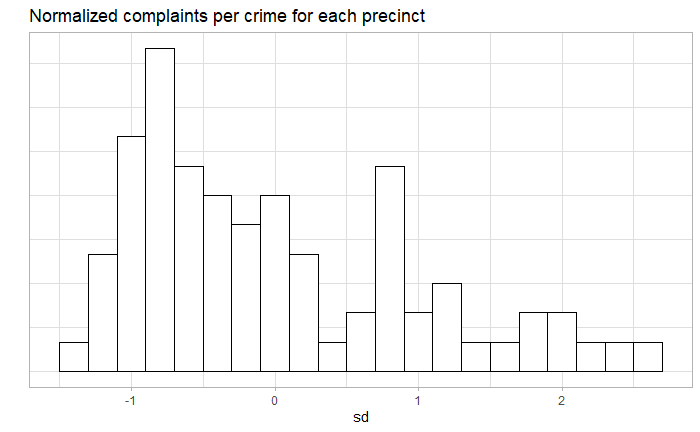

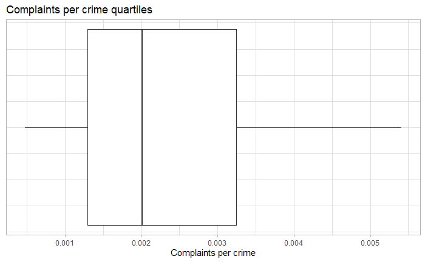